# B620_HW1

Author

MinyoungSo

**Primary Question:** Dose daily concentrations of PM$_{2.5}$ (particulate matter air pollution with aerodynamic diameter less than 2.5 micrometers) decreased in Michigan over the 20 years spanning from 2005 to 2025?

## Step 1. EDA Checklist items 1-5

### 1. Download data

### 2. Read the data

```r
pm25_05 <- read.csv("MI_05.csv")
pm25_25 <- read.csv("MI_25.csv")
```

### 3. Check the dimensions, headers, footers, variable names and variable types

- 2005 Data (pm25_05): Dimension (5280X22)
- 2025 Data (pm25_25): Dimension (9934X22)
- Variables including their names and types are identical in both 2005 and 2025 data sets.

```r
dim(pm25_05)
```

```
[1] 5280   22
```

```r
dim(pm25_25)
```

```
[1] 9934   22
```

```r
head(pm25_05)
```

```
        Date Source   Site.ID POC Daily.Mean.PM2.5.Concentration    Units
1 01/01/2005    AQS 260050003   1                            9.3 ug/m3 LC
2 01/02/2005    AQS 260050003   1                            7.0 ug/m3 LC
3 01/03/2005    AQS 260050003   1                           15.7 ug/m3 LC
4 01/04/2005    AQS 260050003   1                           13.4 ug/m3 LC
5 01/05/2005    AQS 260050003   1                            5.3 ug/m3 LC
6 01/06/2005    AQS 260050003   1                            4.0 ug/m3 LC
  Daily.AQI.Value       Local.Site.Name Daily.Obs.Count Percent.Complete
1              51 966 32nd St (Holland)               1              100
2              39 966 32nd St (Holland)               1              100
3              63 966 32nd St (Holland)               1              100
4              59 966 32nd St (Holland)               1              100
5              29 966 32nd St (Holland)               1              100
6              22 966 32nd St (Holland)               1              100
  AQS.Parameter.Code AQS.Parameter.Description Method.Code
```

[output cut: 27 more lines]

```r
head(pm25_25)
```

```
        Date Source   Site.ID POC Daily.Mean.PM2.5.Concentration    Units
1 01/01/2025    AQS 260050003   1                            3.7 ug/m3 LC
2 01/02/2025    AQS 260050003   1                            4.5 ug/m3 LC
3 01/03/2025    AQS 260050003   1                            3.8 ug/m3 LC
4 01/04/2025    AQS 260050003   1                            3.3 ug/m3 LC
5 01/05/2025    AQS 260050003   1                            4.6 ug/m3 LC
6 01/06/2025    AQS 260050003   1                            3.3 ug/m3 LC
  Daily.AQI.Value       Local.Site.Name Daily.Obs.Count Percent.Complete
1              21 966 32nd St (Holland)               1              100
2              25 966 32nd St (Holland)               1              100
3              21 966 32nd St (Holland)               1              100
4              18 966 32nd St (Holland)               1              100
5              26 966 32nd St (Holland)               1              100
6              18 966 32nd St (Holland)               1              100
  AQS.Parameter.Code AQS.Parameter.Description Method.Code
```

[output cut: 20 more lines]

```r
tail(pm25_05)
```

```
           Date Source   Site.ID POC Daily.Mean.PM2.5.Concentration    Units
5275 09/01/2005    AQS 261639901   1                           12.8 ug/m3 LC
5276 09/07/2005    AQS 261639901   1                           30.4 ug/m3 LC
5277 09/13/2005    AQS 261639901   1                           46.5 ug/m3 LC
5278 09/25/2005    AQS 261639901   1                           24.4 ug/m3 LC
5279 10/01/2005    AQS 261639901   1                           24.0 ug/m3 LC
5280 10/07/2005    AQS 261639901   1                            2.9 ug/m3 LC
     Daily.AQI.Value Local.Site.Name Daily.Obs.Count Percent.Complete
5275              58                               1              100
5276              91                               1              100
5277             128                               1              100
5278              80                               1              100
5279              79                               1              100
5280              16                               1              100
     AQS.Parameter.Code              AQS.Parameter.Description Method.Code
```

[output cut: 27 more lines]

```r
tail(pm25_25)
```

```
           Date Source   Site.ID POC Daily.Mean.PM2.5.Concentration    Units
9929 12/26/2025 AirNow 261630100   1                            5.2 ug/m3 LC
9930 12/27/2025 AirNow 261630100   1                            5.4 ug/m3 LC
9931 12/28/2025 AirNow 261630100   1                           10.7 ug/m3 LC
9932 12/29/2025 AirNow 261630100   1                            2.4 ug/m3 LC
9933 12/30/2025 AirNow 261630100   1                            3.4 ug/m3 LC
9934 12/31/2025 AirNow 261630100   1                            6.7 ug/m3 LC
     Daily.AQI.Value      Local.Site.Name Daily.Obs.Count Percent.Complete
9929              29 Military Park (GHIB)               1              100
9930              30 Military Park (GHIB)               1              100
9931              54 Military Park (GHIB)               1              100
9932              13 Military Park (GHIB)               1              100
9933              19 Military Park (GHIB)               1              100
9934              37 Military Park (GHIB)               1              100
     AQS.Parameter.Code AQS.Parameter.Description Method.Code
```

[output cut: 20 more lines]

```r
str(pm25_05)
```

```
'data.frame':   5280 obs. of  22 variables:
 $ Date                          : chr  "01/01/2005" "01/02/2005" "01/03/2005" "01/04/2005" ...
 $ Source                        : chr  "AQS" "AQS" "AQS" "AQS" ...
 $ Site.ID                       : int  260050003 260050003 260050003 260050003 260050003 260050003 260050003 260050003 260050003 260050003 ...
 $ POC                           : int  1 1 1 1 1 1 1 1 1 1 ...
 $ Daily.Mean.PM2.5.Concentration: num  9.3 7 15.7 13.4 5.3 4 12.6 29 15.5 13.2 ...
 $ Units                         : chr  "ug/m3 LC" "ug/m3 LC" "ug/m3 LC" "ug/m3 LC" ...
 $ Daily.AQI.Value               : int  51 39 63 59 29 22 58 88 63 59 ...
 $ Local.Site.Name               : chr  "966 32nd St (Holland)" "966 32nd St (Holland)" "966 32nd St (Holland)" "966 32nd St (Holland)" ...
 $ Daily.Obs.Count               : int  1 1 1 1 1 1 1 1 1 1 ...
 $ Percent.Complete              : num  100 100 100 100 100 100 100 100 100 100 ...
 $ AQS.Parameter.Code            : int  88101 88101 88101 88101 88101 88101 88101 88101 88101 88101 ...
 $ AQS.Parameter.Description     : chr  "PM2.5 - Local Conditions" "PM2.5 - Local Conditions" "PM2.5 - Local Conditions" "PM2.5 - Local Conditions" ...
 $ Method.Code                   : int  118 118 118 118 118 118 118 118 118 118 ...
 $ Method.Description            : chr  "R & P Model 2025 PM2.5 Sequential w/WINS" "R & P Model 2025 PM2.5 Sequential w/WINS" "R & P Model 2025 PM2.5 Sequential w/WINS" "R & P Model 2025 PM2.5 Sequential w/WINS" ...
 $ CBSA.Code                     : int  26090 26090 26090 26090 26090 26090 26090 26090 26090 26090 ...
 $ CBSA.Name                     : chr  "Holland, MI" "Holland, MI" "Holland, MI" "Holland, MI" ...
 $ State.FIPS.Code               : int  26 26 26 26 26 26 26 26 26 26 ...
 $ State                         : chr  "Michigan" "Michigan" "Michigan" "Michigan" ...
 $ County.FIPS.Code              : int  5 5 5 5 5 5 5 5 5 5 ...
 $ County                        : chr  "Allegan" "Allegan" "Allegan" "Allegan" ...
 $ Site.Latitude                 : num  42.8 42.8 42.8 42.8 42.8 ...
 $ Site.Longitude                : num  -86.1 -86.1 -86.1 -86.1 -86.1 ...
```

```r
str(pm25_25)
```

```
'data.frame':   9934 obs. of  22 variables:
 $ Date                          : chr  "01/01/2025" "01/02/2025" "01/03/2025" "01/04/2025" ...
 $ Source                        : chr  "AQS" "AQS" "AQS" "AQS" ...
 $ Site.ID                       : int  260050003 260050003 260050003 260050003 260050003 260050003 260050003 260050003 260050003 260050003 ...
 $ POC                           : int  1 1 1 1 1 1 1 1 1 1 ...
 $ Daily.Mean.PM2.5.Concentration: num  3.7 4.5 3.8 3.3 4.6 3.3 3 2.8 7.7 17.7 ...
 $ Units                         : chr  "ug/m3 LC" "ug/m3 LC" "ug/m3 LC" "ug/m3 LC" ...
 $ Daily.AQI.Value               : int  21 25 21 18 26 18 17 16 43 67 ...
 $ Local.Site.Name               : chr  "966 32nd St (Holland)" "966 32nd St (Holland)" "966 32nd St (Holland)" "966 32nd St (Holland)" ...
 $ Daily.Obs.Count               : int  1 1 1 1 1 1 1 1 1 1 ...
 $ Percent.Complete              : num  100 100 100 100 100 100 100 100 100 100 ...
 $ AQS.Parameter.Code            : int  88101 88101 88101 88101 88101 88101 88101 88101 88101 88101 ...
 $ AQS.Parameter.Description     : chr  "PM2.5 - Local Conditions" "PM2.5 - Local Conditions" "PM2.5 - Local Conditions" "PM2.5 - Local Conditions" ...
 $ Method.Code                   : int  170 170 170 170 170 170 170 170 170 170 ...
 $ Method.Description            : chr  "Met One BAM-1020 Mass Monitor w/VSCC" "Met One BAM-1020 Mass Monitor w/VSCC" "Met One BAM-1020 Mass Monitor w/VSCC" "Met One BAM-1020 Mass Monitor w/VSCC" ...
 $ CBSA.Code                     : int  26090 26090 26090 26090 26090 26090 26090 26090 26090 26090 ...
 $ CBSA.Name                     : chr  "Holland, MI" "Holland, MI" "Holland, MI" "Holland, MI" ...
 $ State.FIPS.Code               : int  26 26 26 26 26 26 26 26 26 26 ...
 $ State                         : chr  "Michigan" "Michigan" "Michigan" "Michigan" ...
 $ County.FIPS.Code              : int  5 5 5 5 5 5 5 5 5 5 ...
 $ County                        : chr  "Allegan" "Allegan" "Allegan" "Allegan" ...
 $ Site.Latitude                 : num  42.8 42.8 42.8 42.8 42.8 ...
 $ Site.Longitude                : num  -86.1 -86.1 -86.1 -86.1 -86.1 ...
```

### 4. Check distribution of the key variable (PM2.5)

The key variable is Daily.Mean.PM2.5.Concentration. In 2025 data, its mean is lower and the distribution skews more left side compared to the 2005 data, indicating an overall decrease in daily PM$_{2.5}$ concentrations in 2025. However, the maximum value in 2025 is higher than the maximum value in 2005, suggesting that at least one day in 2025 experienced a higher level of PM$_{2.5}$ pollution than any day observed in 2005 in Michigan.

```r
summary(pm25_05$ Daily.Mean.PM2.5.Concentration)
```

```
   Min. 1st Qu.  Median    Mean 3rd Qu.    Max.
   0.00    6.20   11.00   13.77   18.70   81.60
```

```r
summary(pm25_25$ Daily.Mean.PM2.5.Concentration)
```

```
   Min. 1st Qu.  Median    Mean 3rd Qu.    Max.
  0.000   4.000   6.300   8.304  10.100 116.000
```

```r
summary(pm25_05$ Daily.Mean.PM2.5.Concentration)
```

```
   Min. 1st Qu.  Median    Mean 3rd Qu.    Max.
   0.00    6.20   11.00   13.77   18.70   81.60
```

```r
summary(pm25_25$ Daily.Mean.PM2.5.Concentration)
```

```
   Min. 1st Qu.  Median    Mean 3rd Qu.    Max.
  0.000   4.000   6.300   8.304  10.100 116.000
```

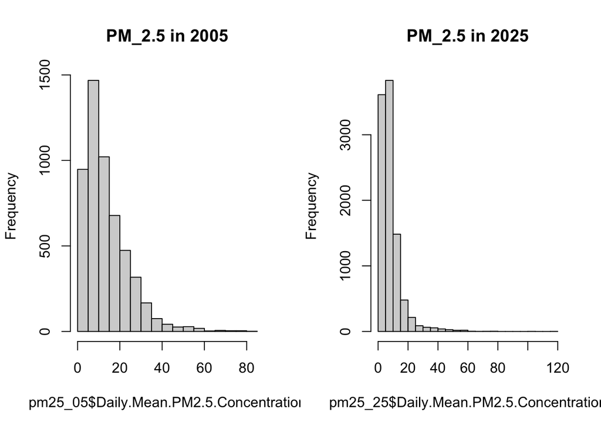

```r
layout(matrix(1:2, nrow=1))
hist(pm25_05$ Daily.Mean.PM2.5.Concentration,
     breaks = seq(min(pm25_05$Daily.Mean.PM2.5.Concentration), max(pm25_05$Daily.Mean.PM2.5.Concentration)+5, by = 5),
     main = "PM_2.5 in 2005")

hist(pm25_25$ Daily.Mean.PM2.5.Concentration, breaks =seq(min(pm25_25$Daily.Mean.PM2.5.Concentration), max(pm25_25$Daily.Mean.PM2.5.Concentration)+5, by = 5),
     main = "PM_2.5 in 2025")
```

```r
layout(1)
```

### 5. Summary of findings

2025 Data (9934X22) has more observation data than 2005 Data set (5280X22), but their variables are identical including their names and types.

The average of daily concentrations of particulate matter(PM) air pollution with aerodynamic diameter less than 2.5 micrometers (PM$_{2.5}$) in Michigan decreased from 2005 (13.77 $ug/m^3$) to 2025 (8.30 $ug/m^3$), indicating a substantial improvement in overall air quality over the past two decades. However, the concentration observed on the most polluted day (Max. value) in 2025 (116.00 $ug/m^3$) was considerably higher than that in 2005 (81.60 $ug/m^3$), suggesting that despite long-term improvements, extreme pollution events have not been eliminated.

## Step 2. Combine the two years of data with a new column for “Year”.

### 1. Create a new column for year

```r
library(dplyr)
library(lubridate)
# Create Year variable
pm25_05 <- pm25_05 |>
  mutate(
    Date = mdy(Date),
    Year = year(Date)
  )

pm25_25 <- pm25_25 |>
  mutate(
    Date = mdy(Date),
    Year = year(Date)
  )
```

### 2. Combine the two years of data and Change the name of key variables

```r
# Combine datasets
pm25_all <- bind_rows(pm25_05, pm25_25)

# Rename key variables
pm25_all <- pm25_all |>
  rename(
    pm25 = Daily.Mean.PM2.5.Concentration,
    lat  = Site.Latitude,
    lon  = Site.Longitude,
    site = Site.ID
  )

# Check
dim(pm25_all)
```

```
[1] 15214    23
```

```r
str(pm25_all)
```

```
'data.frame':   15214 obs. of  23 variables:
 $ Date                     : Date, format: "2005-01-01" "2005-01-02" ...
 $ Source                   : chr  "AQS" "AQS" "AQS" "AQS" ...
 $ site                     : int  260050003 260050003 260050003 260050003 260050003 260050003 260050003 260050003 260050003 260050003 ...
 $ POC                      : int  1 1 1 1 1 1 1 1 1 1 ...
 $ pm25                     : num  9.3 7 15.7 13.4 5.3 4 12.6 29 15.5 13.2 ...
 $ Units                    : chr  "ug/m3 LC" "ug/m3 LC" "ug/m3 LC" "ug/m3 LC" ...
 $ Daily.AQI.Value          : int  51 39 63 59 29 22 58 88 63 59 ...
 $ Local.Site.Name          : chr  "966 32nd St (Holland)" "966 32nd St (Holland)" "966 32nd St (Holland)" "966 32nd St (Holland)" ...
 $ Daily.Obs.Count          : int  1 1 1 1 1 1 1 1 1 1 ...
 $ Percent.Complete         : num  100 100 100 100 100 100 100 100 100 100 ...
 $ AQS.Parameter.Code       : int  88101 88101 88101 88101 88101 88101 88101 88101 88101 88101 ...
 $ AQS.Parameter.Description: chr  "PM2.5 - Local Conditions" "PM2.5 - Local Conditions" "PM2.5 - Local Conditions" "PM2.5 - Local Conditions" ...
 $ Method.Code              : int  118 118 118 118 118 118 118 118 118 118 ...
 $ Method.Description       : chr  "R & P Model 2025 PM2.5 Sequential w/WINS" "R & P Model 2025 PM2.5 Sequential w/WINS" "R & P Model 2025 PM2.5 Sequential w/WINS" "R & P Model 2025 PM2.5 Sequential w/WINS" ...
 $ CBSA.Code                : int  26090 26090 26090 26090 26090 26090 26090 26090 26090 26090 ...
 $ CBSA.Name                : chr  "Holland, MI" "Holland, MI" "Holland, MI" "Holland, MI" ...
 $ State.FIPS.Code          : int  26 26 26 26 26 26 26 26 26 26 ...
 $ State                    : chr  "Michigan" "Michigan" "Michigan" "Michigan" ...
 $ County.FIPS.Code         : int  5 5 5 5 5 5 5 5 5 5 ...
 $ County                   : chr  "Allegan" "Allegan" "Allegan" "Allegan" ...
 $ lat                      : num  42.8 42.8 42.8 42.8 42.8 ...
 $ lon                      : num  -86.1 -86.1 -86.1 -86.1 -86.1 ...
 $ Year                     : num  2005 2005 2005 2005 2005 ...
```

## Step 3. Create a basic map

### 1. Create a map of location of the monitoring sites

```r
library(leaflet)

# Prepare the data
sites <- pm25_all |>
  distinct(site, lat, lon, Year) |>
  mutate(Year = as.factor(Year))
sites
```

```
        site      lat       lon Year
1  260050003 42.76779 -86.14858 2005
2  260170014 43.57139 -83.89072 2005
3  260210014 42.19779 -86.30969 2005
4  260330901 46.49363 -84.36421 2005
5  260330902 46.48169 -84.33171 2005
6  260330903 46.45402 -84.60675 2005
7  260430002 46.13939 -87.90736 2005
8  260490021 43.04722 -83.67016 2005
9  260650012 42.73862 -84.53463 2005
10 260710001 46.15983 -88.11976 2005
11 260770008 42.27807 -85.54189 2005
12 260810020 42.98417 -85.67134 2005
13 260839000 47.91670 -89.15008 2005
14 260990009 42.73139 -82.79346 2005
```

[output cut: 47 more lines]

```r
# Create a color
pal <- colorFactor(palette = c("blue", "red"), domain = sites$Year)
# Leaflet Map
leaflet(sites) |>
  addTiles() |>  # standard OpenStreetMap base layer
  addCircleMarkers(
    lng = ~lon,
    lat = ~lat,
    color = ~pal(Year),
    radius = 2,
    opacity = 0.5,
    fillOpacity = 0.5,
    popup = ~paste0("<b>Site ID:</b> ", site, "<br>",
                    "<b>Year:</b> ", Year) # Click for info
  ) |>
  addLegend(
    "bottomright",
    pal = pal,
    values = ~Year,
    title = "Monitoring Site",
    opacity = 1
  )
```

[interactive chart not shown]

## Step 4. Data issues

### 1. Missing or implausible data

No missing and implausible values (PM$_{2.5} < 0$ or PM$_{2.5} > 300$) of PM$_{2.5}$ were found in the combined data set.

```r
# Implausible values
implausible_pm25 <- pm25_all |>
  filter(pm25 < 0 | pm25 > 300)
# >300: Hazadous level of AQI (PM_2.5, PM_10 and ozone). Emergency condition by AQI Basics Table. https://www.airnow.gov/aqi/aqi-basics/

# Missing and implausible PM2.5 data
pm25_all |>
  group_by(Year) |>
  summarise(
    total_obs = n(),
    missing_pm25 = sum(is.na(pm25)),
    prop_missing_pm25 = mean(is.na(pm25)),
    implausible_pm25 = nrow(implausible_pm25)
  )
```

```
# A tibble: 2 × 5
   Year total_obs missing_pm25 prop_missing_pm25 implausible_pm25
  <dbl>     <int>        <int>             <dbl>            <int>
1  2005      5280            0                 0                0
2  2025      9934            0                 0                0
```

### 2. Distribution of method code and analysis of two most common methods

Two sampling methods dominated the dataset: the R & P Model 2025 PM2.5 Sequential (Code 118) and the Teledyne T640 (Code 636). Together, these accounted for a major share of the data, with Code 118 contributing 4,355 observations and Code 636 contributing 3,941 observations out of the 15,214 total.

There was a distinct temporal shift in the technology used. Method 118 was the dominant method in 2005, covering 82% of that year’s records, but was entirely absent in 2025. Conversely, Method 636 was used exclusively in 2025 (40% of observations) and was not used in 2005.

These methods represent a fundamental difference in measurement mechanics. Method 118 utilizes gravimetric analysis, which determines mass by weighing particles collected on filters. In contrast, Method 636 utilizes broadband spectroscopy, which measures the interaction of a wide range of electromagnetic wavelengths with particles (Wang et al., 2016). This shift in technology has significantly improved sensitivity. According to the federal Method Detection Limit (MDL, 99% confidence) in the EPA sampling table, the gravimetric method (Code 118) has a limit of 2.0 $\mu g/m^3$, whereas the newer broadband method (Code 636) offers a much finer precision of 0.1 $\mu g/m^3$.

Because method codes are not always unique identifiers across the EPA method table, I validated these codes for our data set (pm_all). By cross-referencing Method.Description and AQS.Parameter.Code, I confirmed that Code 118 and Code 636 map to unique, consistent sampling configurations within the 2005 and 2025 data, respectively.

(Wang et al, 2016, DOI:10.1080/10962247.2016.1201022)

```r
# Distribution of method codes overall
method_dist <- as.data.frame(table(pm25_all$Method.Code))
colnames(method_dist) <- c("method.code", "frequency")
method_dist <- method_dist[order(-method_dist$frequency), ]
method_dist
```

```
  method.code frequency
1         118      4355
4         636      3941
3         170      1741
5         638      1336
8         810       607
2         145       324
6         707       323
7         781        44
```

```r
# Top two common methods
top2_methods <- head(method_dist, 2)
top2_methods
```

```
  method.code frequency
1         118      4355
4         636      3941
```

```r
# Proportion of annual usage of two methods in each year
target_method_codes <- top2_methods$method.code
method_usage_summary <- pm25_all |>
  group_by(Year) |>
  mutate(total_annual_obs = n()) |>
  group_by(Year, Method.Code) |>
  summarise(
    count = n(),
    total_annual_obs = first(total_annual_obs),
    proportion = count / total_annual_obs,
    .groups = "drop"
  ) |>
  filter(Method.Code %in% target_method_codes) |>
  arrange(Year, desc(proportion))
print(method_usage_summary)
```

```
# A tibble: 2 × 5
   Year Method.Code count total_annual_obs proportion
  <dbl>       <int> <int>            <int>      <dbl>
1  2005         118  4355             5280      0.825
2  2025         636  3941             9934      0.397
```

```r
# Confirmation existance of other combinations
sum(pm25_all$Year == 2005 & pm25_all$Method.Code == 636, na.rm = TRUE)
```

```
[1] 0
```

```r
sum(pm25_all$Year == 2025 & pm25_all$Method.Code == 118, na.rm = TRUE)
```

```
[1] 0
```

```r
# Confirmation of method information of top two methods in 2025 and 2005 data sets.
subset_2005_118 <- pm25_all |>
  filter(Year == 2005, Method.Code == 118)
subset_2025_636 <- pm25_all |>
  filter(Year == 2025, Method.Code == 636)
#print(subset_2005_118)
#print(subset_2025_636)

pm25_all  |> count(Method.Code, Method.Description, AQS.Parameter.Code)
```

```
  Method.Code                                             Method.Description
1         118                       R & P Model 2025 PM2.5 Sequential w/WINS
2         145          R & P Model 2025 PM-2.5 Sequential Air Sampler w/VSCC
3         170                           Met One BAM-1020 Mass Monitor w/VSCC
4         636      Teledyne T640 at 5.0 LPM w/Network Data Alignment enabled
5         638   Teledyne T640X at 16.67 LPM w/Network Data Alignment enabled
6         707 IMPROVE Module A with Cyclone Inlet-Teflon Filter, 2.2 sq. cm.
7         781                                 SINGLE-FILTR WINS 2.5UM IMPACT
8         810                                  Met One SASS/SuperSASS Teflon
9          NA
  AQS.Parameter.Code    n
1              88101 4355
2              88101  324
3              88101 1741
4              88101 3941
5              88101 1336
6              88502  323
7              88502   44
8              88502  607
9              88101 2543
```

```r
subset_2005_118 |> count(Method.Code, Method.Description, AQS.Parameter.Code)
```

```
  Method.Code                       Method.Description AQS.Parameter.Code    n
1         118 R & P Model 2025 PM2.5 Sequential w/WINS              88101 4355
```

```r
subset_2025_636 |> count(Method.Code, Method.Description, AQS.Parameter.Code)
```

```
  Method.Code                                        Method.Description
1         636 Teledyne T640 at 5.0 LPM w/Network Data Alignment enabled
  AQS.Parameter.Code    n
1              88101 3941
```

### 3. Propostion of missing PM$_{2.5}$ value and missing method code for each year.

There are no missing PM$_{2.5}$ concentration values in the 2005 and 2025 dataset, but 26% of the daily observations in 2025 lack a recorded Method Code. This missing code data, combined with the fundamental shift in sampling technology, complicates temporal comparisons. The transition from the gravimetric Method 118 (MDL: 2.0 $\mu g/m^3$) in 2005 to the broadband Method 636 (MDL: 0.1 $\mu g/m^3$) in 2025 creates a disparity in sensitivity. This discrepancy is particularly pronounced at lower concentrations (below 5 $\mu g/m^3$), where the older 2005 technology lacks the precision to accurately capture levels that the 2025 instrumentation detects easily. Consequently, the validity of the observed decrease in PM$_{2.5}$ over this 20-year period is weakened by these methodological inconsistencies. The coarser resolution of the 2005 data introduces uncertainty at the lower bounds, while the high rate of missing method codes in 2025 limits our ability to fully control for instrument bias. Therefore, the calculated reduction trend should be interpreted with caution.

```r
# Proportion of missing pm_25 and missing methods in year

missing_summary <- pm25_all |>
  group_by(Year) |>
  summarise(
    prop_missing_pm25   = mean(is.na(pm25)),
    prop_missing_method = mean(is.na(Method.Code)),
    .groups = "drop"
  )

missing_summary
```

```
# A tibble: 2 × 3
   Year prop_missing_pm25 prop_missing_method
  <dbl>             <dbl>               <dbl>
1  2005                 0               0
2  2025                 0               0.256
```

## Step 5. Create data visualizations

### Level 1. State

As we observed at the Step 1., the average of daily concentrations of PM$_{2.5}$ in Michigan decreased from 2005 (13.77 $ug/m^3$) to 2025 (8.30 $ug/m^3$), implying an improvement in state-wise air quality over the 20 years from 2005 to 2025. However, two observations in 2025 were considerably higher than any of observations in 2005 in the box plot, suggesting that extreme pollution events still remain a risk.

```r
library(ggplot2)

pm25_all |>
  group_by(Year) |>
  summarise(
    mean_pm25 = mean(pm25, na.rm = TRUE),
    median_pm25 = median(pm25, na.rm = TRUE),
    sd_pm25 = sd(pm25, na.rm = TRUE)
  )
```

```
# A tibble: 2 × 4
   Year mean_pm25 median_pm25 sd_pm25
  <dbl>     <dbl>       <dbl>   <dbl>
1  2005     13.8         11     10.4
2  2025      8.30         6.3    7.42
```

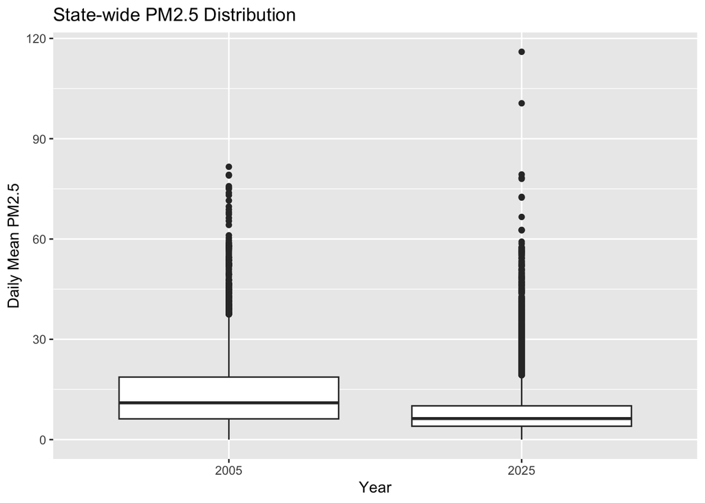

```r
ggplot(pm25_all, aes(x = factor(Year), y = pm25)) +
  geom_boxplot() +
  labs(
    title = "State-wide PM2.5 Distribution",
    x = "Year",
    y = "Daily Mean PM2.5"
  )
```

### Level 2. County

For the majority of these counties, the “body” of the violin, representing the most frequent PM$_{2.5}$ concentrations, has shifted downward, indicating a general improvement in baseline air quality over the 20-year period. However, the upper tails of the distributions remain concerning. In many cases, these tails are equal to or longer than those observed in 2005, mirroring the pattern seen in the state-wide analysis. This suggests that while average air quality has improved, extreme high-pollution events persist. These outliers require further investigation to identify their sources and to establish targeted policies for risk reduction.

Additionally, significant data gaps exist for 2025. Counties such as Berrien, Monroe, Muskegon, and Saginaw, which exhibited relatively high pollution levels in 2005, were not monitored in 2025. Given their historical pollution profiles, reinstating test sampling in these areas is strongly recommended to ensure accurate, state-wide air quality assessment.

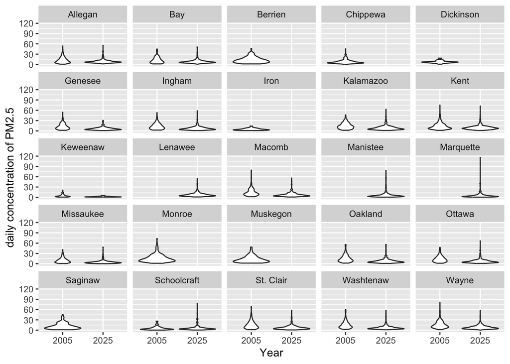

```r
county_summary <- pm25_all |>
  group_by(County, Year) |>
  summarise(
    mean_pm25 = mean(pm25, na.rm = TRUE),
    median_pm25 = median(pm25, na.rm = TRUE),
    sd_pm25 = sd(pm25, na.rm = TRUE)
  )
ggplot(pm25_all, aes(x = factor(Year), y = pm25)) +
  geom_violin() +
  facet_wrap(~County) +
  labs(y = "daily concentration of PM2.5", x = "Year")
```

### Level 3. CITY (Wayne County)

Analysis of the four Wayne County monitoring sites with data for both 2005 and 2025 reveals a consistent decline in annual average PM$_{2.5}$ concentrations over the 20-year period. However, the monitoring network has undergone significant reconfiguration; six sites were active exclusively in 2005, while five new sites were introduced for 2025.

This unbalanced panel structure introduces potential spatial bias. Because the specific locations monitored in 2005 differ from those in 2025, it is difficult to distinguish true county-wide air quality improvements. Consequently, extrapolating the trends from the four continuous sites to the entire county requires caution and would benefit from further spatial analysis.

```r
wayne_data <- pm25_all |>
  filter(County == "Wayne")

wayne_summary <- wayne_data |>
  group_by(site, Year) |>
  summarise(
    .groups = "drop_last",
    mean_pm25 = mean(pm25, na.rm = TRUE)
  )

wayne_sites <- wayne_data |>
  distinct(site, lat, lon, Year)

pal2 <- colorFactor(c("blue", "red"), wayne_sites$Year)

leaflet(wayne_sites) |>
  #addProviderTiles(providers$CartoDB.Positron) |>
    addTiles() |>
    addCircleMarkers(
    lng = ~lon,
    lat = ~lat,
    color = ~pal2(Year),
    radius = 4,
    popup = ~paste("Site:", site,
                   "<br>Year:", Year)
  )
```

[interactive chart not shown]

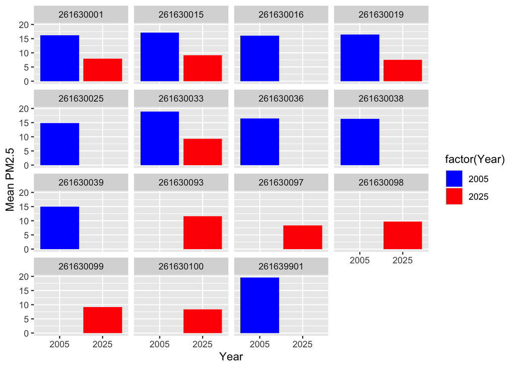

```r
ggplot(wayne_summary, aes(x = factor(Year), y = mean_pm25, fill = factor(Year))) +
  geom_col() +  # <--- Changed from geom_bar() to geom_col()
  facet_wrap(~site) +
  scale_fill_manual(values = c("blue", "red")) +
  scale_x_discrete(labels = c("2005", "2025")) +
  labs(y = "Mean PM2.5", x = "Year")
```